# Matching Networks(Metrics Based Method): Omniglot Dataset

In this tutorial, we will learn how to create Matching Networks, and train it on Omniglot Dataset.

###### To begin, Let's first understand what Omniglot dataset is:

The Omniglot data set is designed for developing more human-like learning algorithms. It contains 1623 different handwritten characters from 50 different alphabets. Each of the 1623 characters was drawn online via Amazon's Mechanical Turk by 20 different people. Each image is paired with stroke data, a sequences of [x,y,t] coordinates with time (t) in milliseconds. For more details, please refer : https://github.com/brendenlake/omniglot

#### Matching Networks Architecture

Matching networks, in general, proposes a framework which learns a network that maps a small training dataset and test unlabeled example to same embeddings space. Matching networks aim to learn the proper embeddings representation of small training dataset and use differentiable k-NN with cosine similarity measure to ensure whether a test data point is something ever seen or not.

Matching networks are designed to be two-fold:

Modeling level: At Modeling level, they proposed Matching nets, which uses advances made in attention and memory that enable fast and efficient learning.

Training procedure: At Training Level, they have one condition that distribution of training and test set must be the same. For example: show a few examples per class, switching the task from minibatch to minibatch, similar to how it will be tested when presented with a few examples of a new task.

[figure not shown]

As we have learned, Matching Networks Architecture implementation consists of following 5 important parts:

1. Embeddings Extractor, g.
2. Full Context Embeddings, Bi-directional LSTM, f
3. Cosine Similarity Distance Function, c
4. Attention Model: Softmax(c)
5. Loss Function: Cross Entropy Loss

##### Step 1: Import all necessary libraries

```python
!pip install tqdm
!pip install matplotlib
```

```
You are using pip version 9.0.1, however version 20.0.2 is available.
You are using pip version 9.0.1, however version 20.0.2 is available.
```

```python
import numpy as np
import torch
import torch.nn as nn
import math
import numpy as np
import torch.nn.functional as F
from torch.autograd import Variable
import tqdm
import torch.backends.cudnn as cudnn
from torch.optim.lr_scheduler import ReduceLROnPlateau
import matplotlib.pyplot as plt
%matplotlib inline
```

#### Step 2: We will load omniglot dataset, tranformed in .npy format using helper script.

In helper script, we are just loading data in size format: [total_number,character,28,28].  
for more details, go through helper.py script.

```python
x = np.load('data/data.npy') # Load Data
print (x.shape)
print (type(x))
x = np.reshape(x, newshape=(x.shape[0], x.shape[1], 28, 28, 1)) # expand dimension from (x.shape[0],x.shape[1],28,28)
np.random.shuffle(x) # shuffle dataset
x_train, x_val, x_test = x[:1200], x[1200:1411], x[1411:] # divide dataset in to train, val,ctest
batch_size = 16 # setting batch_size
n_classes = x.shape[0] # total number of classes
classes_per_set = 20 # Number of classes per set
samples_per_class = 1 # as we are choosing it to be one shot learning, so we have 1 sample
print (x_train.shape)
```

```
(1623, 20, 28, 28)
<class 'numpy.ndarray'>
(1200, 20, 28, 28, 1)
```

##### Preprocess Images: Here we have use normalization method.

```python
def processes_batch(data, mu, sigma):
    return (data - mu) / sigma

# Normalize Dataset
x_train = processes_batch(x_train, np.mean(x_train), np.std(x_train))
x_val = processes_batch(x_val, np.mean(x_val), np.std(x_val))
x_test = processes_batch(x_test, np.mean(x_test), np.std(x_test))

# Defining dictionary of dataset
datatset = {"train": x_train, "val": x_val, "test": x_test}
```

Let's Visualize example of one character written by 20 people.

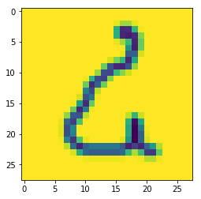

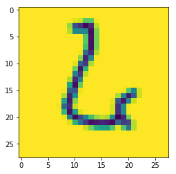

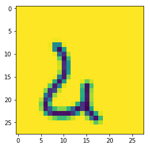

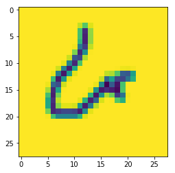

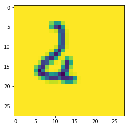

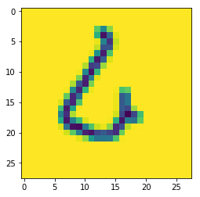

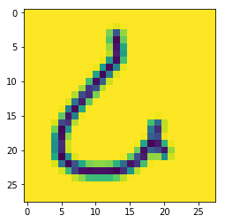

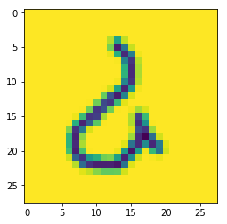

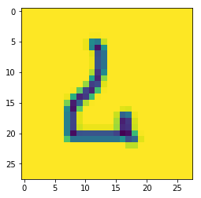

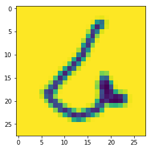

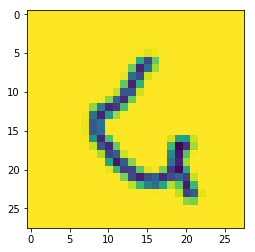

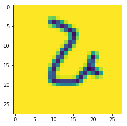

[8 more figures not shown]

```python
temp = x_train[0,:,:,:,:]
for i in range(0,20):
    plt.figure()
    plt.imshow(temp[i,:,:,0])
```

###### Step 3: Training Data Processing

To Load Omniglot dataset, and prepare it for Matching Networks Architecture, we need to create:

1. Label Set: Variable choose_label
2. Support Set: support_set_x, support_set_y
3. Batch from Suppport Set Examples

Let's first create a batch which can give a support set, and target set.

```python
def sample_batch(data):
        """
        Generates sample batch
        :param : data - one of(train,test,val) our current dataset shape [total_classes,20,28,28,1]
        :return: [support_set_x,support_set_y,target_x,target_y] for Matching Networks
        """
        support_set_x = np.zeros((batch_size, classes_per_set, samples_per_class, data.shape[2],
                                  data.shape[3], data.shape[4]), np.float32)
        support_set_y = np.zeros((batch_size, classes_per_set, samples_per_class), np.int32)

        target_x = np.zeros((batch_size, data.shape[2], data.shape[3], data.shape[4]), np.float32)
        target_y = np.zeros((batch_size, 1), np.int32)
        for i in range(batch_size):
            choose_classes = np.random.choice(data.shape[0], size=classes_per_set, replace=False) # choosing random classes
            choose_label = np.random.choice(classes_per_set, size=1) # label set
            choose_samples = np.random.choice(data.shape[1], size=samples_per_class + 1, replace=False)
            x_temp = data[choose_classes] # choosing classes
            x_temp = x_temp[:, choose_samples] # choosing sample batch from classes chosen outputs 20X2X28X28X1
            y_temp = np.arange(classes_per_set) # will return [0,1,2,3,...,19]
            support_set_x[i] = x_temp[:, :-1]
            support_set_y[i] = np.expand_dims(y_temp[:], axis=1) # expand dimension
            target_x[i] = x_temp[choose_label, -1]
            target_y[i] = y_temp[choose_label]
        return support_set_x, support_set_y, target_x, target_y # returns support of [batch_size, 20 classes per set, 1 sample, 28, 28,1]

def get_batch(dataset_name):
        """
        gen batch while training
        :param dataset_name: The name of dataset(one of "train","val","test")
        :return: a batch images
        """
        support_set_x, support_set_y, target_x, target_y = sample_batch(datatset[dataset_name])
        support_set_x = support_set_x.reshape((support_set_x.shape[0], support_set_x.shape[1] * support_set_x.shape[2],
                                               support_set_x.shape[3], support_set_x.shape[4], support_set_x.shape[5]))
        support_set_y = support_set_y.reshape(support_set_y.shape[0], support_set_y.shape[1] * support_set_y.shape[2])
        return support_set_x, support_set_y, target_x, target_y
```

If you recall, Matching Networks architecture, you will remember that there are mainly 4 parts of network:

1. Embeddings extractor(g)
2. Full-Context Embeddings(f)
3. Attention Model(a)
4. Distance Function(c)

so, In this section first we will create a classifier.

##### Step 4: Create an Embeddings extractor

```python
def convLayer(in_channels, out_channels, dropout_prob=0.0):
    """
    :param dataset_name: The name of dataset(one of "train","val","test")
    :return: a batch images
    """
    cnn_seq = nn.Sequential(
        nn.Conv2d(in_channels, out_channels, 3, 1, 1),
        nn.ReLU(True),
        nn.BatchNorm2d(out_channels),
        nn.MaxPool2d(kernel_size=2, stride=2),
        nn.Dropout(dropout_prob)
    )
    return cnn_seq

class Embeddings_extractor(nn.Module):
    def __init__(self, layer_size=64, num_channels=1, dropout_prob=0.5, image_size=28):
        super(Embeddings_extractor, self).__init__()
        """
        Build a CNN to produce embeddings
        :param layer_size:64(default)
        :param num_channels:
        :param keep_prob:
        :param image_size:
        """
        self.layer1 = convLayer(num_channels, layer_size, dropout_prob)
        self.layer2 = convLayer(layer_size, layer_size, dropout_prob)
        self.layer3 = convLayer(layer_size, layer_size, dropout_prob)
        self.layer4 = convLayer(layer_size, layer_size, dropout_prob)

        finalSize = int(math.floor(image_size / (2 * 2 * 2 * 2)))
        self.outSize = finalSize * finalSize * layer_size

    def forward(self, image_input):
        """
        :param: Image
        :return: embeddings
        """
        x = self.layer1(image_input)
        x = self.layer2(x)
        x = self.layer3(x)
        x = self.layer4(x)
        x = x.view(x.size()[0], -1)
        return x
```

##### step 5: Create an Attention model after classifier.

a(x,x^)= softmax of cosine similarities

```python
class AttentionalClassify(nn.Module):
    def __init__(self):
        super(AttentionalClassify, self).__init__()

    def forward(self, similarities, support_set_y):
        """
        Products pdfs over the support set classes for the target set image.
        :param similarities: A tensor with cosine similarites of size[batch_size,sequence_length]
        :param support_set_y:[batch_size,sequence_length,classes_num]
        :return: Softmax pdf shape[batch_size,classes_num]
        """
        softmax = nn.Softmax(dim=1)
        softmax_similarities = softmax(similarities)
        preds = softmax_similarities.unsqueeze(1).bmm(support_set_y).squeeze()
        return preds
```

#### Step 6: Create a Distance Network, which will take output from Test Image, and training embeddings, to calculate the Distance.

find cosine similarities between support set and input_test_image

```python
class DistanceNetwork(nn.Module):
    """
    This model calculates the cosine distance between each of the support set embeddings and
    the target image embeddings.
    """

    def __init__(self):
        super(DistanceNetwork, self).__init__()

    def forward(self, support_set, input_image):
        """
        forward pass
        :param support_set:the embeddings of the support set images.shape[sequence_length,batch_size,64]
        :param input_image: the embedding of the target image,shape[batch_size,64]
        :return:shape[batch_size,sequence_length]
        """
        eps = 1e-10
        similarities = []
        for support_image in support_set:
            sum_support = torch.sum(torch.pow(support_image, 2), 1)
            support_manitude = sum_support.clamp(eps, float("inf")).rsqrt()
            dot_product = input_image.unsqueeze(1).bmm(support_image.unsqueeze(2)).squeeze()
            cosine_similarity = dot_product * support_manitude
            similarities.append(cosine_similarity)
        similarities = torch.stack(similarities)
        return similarities.t()
```

##### Step 7: Create a Bi-directional LSTM, which is taking input and output from Test-image, and put them in same embeddings space.

If we wish to use full-context embeddings, Matching Networks introduced Bi-directional LSTM for it.

```python
class BidirectionalLSTM(nn.Module):
    def __init__(self, layer_size, batch_size, vector_dim):
        super(BidirectionalLSTM, self).__init__()
        """
        Initial a muti-layer Bidirectional LSTM
        :param layer_size: a list of each layer'size
        :param batch_size:
        :param vector_dim:
        """
        self.batch_size = batch_size
        self.hidden_size = layer_size[0]
        self.vector_dim = vector_dim
        self.num_layer = len(layer_size)
        self.lstm = nn.LSTM(input_size=self.vector_dim, num_layers=self.num_layer, hidden_size=self.hidden_size,
                            bidirectional=True)
        self.hidden = (Variable(torch.zeros(self.lstm.num_layers * 2, self.batch_size, self.lstm.hidden_size),requires_grad=False),
                Variable(torch.zeros(self.lstm.num_layers * 2, self.batch_size, self.lstm.hidden_size),requires_grad=False))

    def repackage_hidden(self,h):
        """Wraps hidden states in new Variables,
        to detach them from their history."""
        if type(h) == torch.Tensor:
            return Variable(h.data)
        else:
            return tuple(self.repackage_hidden(v) for v in h)

    def forward(self, inputs):
        self.hidden = self.repackage_hidden(self.hidden)
        output, self.hidden = self.lstm(inputs, self.hidden)
        return output
```

##### Step 8: Let's club all small modules we made, and create a matching network.

```python
class MatchingNetwork(nn.Module):
    def __init__(self, keep_prob, batch_size=32, num_channels=1, learning_rate=1e-3, fce=False, num_classes_per_set=20, \
                 num_samples_per_class=1, image_size=28):
        """
        Matching Network
        :param keep_prob: dropout rate
        :param batch_size:
        :param num_channels:
        :param learning_rate:
        :param fce: Flag indicating whether to use full context embeddings(i.e. apply an LSTM on the CNN embeddings)
        :param num_classes_per_set:
        :param num_samples_per_class:
        :param image_size:
        """
        super(MatchingNetwork, self).__init__()
        self.batch_size = batch_size
        self.keep_prob = keep_prob
        self.num_channels = num_channels
        self.learning_rate = learning_rate
        self.num_classes_per_set = num_classes_per_set
        self.num_samples_per_class = num_samples_per_class
        self.image_size = image_size
        # Let's set all peices of Matching Networks Architecture
        self.g = Embeddings_extractor(layer_size=64, num_channels=num_channels, dropout_prob=keep_prob, image_size=image_size)
        self.f = fce # if we are considering full-context embeddings
        self.c = DistanceNetwork() # cosine distance among embeddings
        self.a = AttentionalClassify() # softmax of cosine distance of embeddings
        if self.f:
            self.lstm = BidirectionalLSTM(layer_size=[32], batch_size=self.batch_size, vector_dim=self.g.outSize)

    def forward(self, support_set_images, support_set_y_one_hot, target_image, target_y):
        """
        Main process of the network
        :param support_set_images: shape[batch_size,sequence_length,num_channels,image_size,image_size]
        :param support_set_y_one_hot: shape[batch_size,sequence_length,num_classes_per_set]
        :param target_image: shape[batch_size,num_channels,image_size,image_size]
        :param target_y:
        :return:
        """
        # produce embeddings for support set images
        encoded_images = []
        for i in np.arange(support_set_images.size(1)):
            gen_encode = self.g(support_set_images[:, i, :, :])
            encoded_images.append(gen_encode)

        # produce embeddings for target images
        gen_encode = self.g(target_image)
        encoded_images.append(gen_encode)
        output = torch.stack(encoded_images,dim=0)

        # if we are considering full-context embeddings
        if self.f:
            output = self.lstm(output)

        # get similarities between support set embeddings and target
        similarites = self.c(support_set=output[:-1], input_image=output[-1])

        # produce predictions for target probabilities
        preds = self.a(similarites, support_set_y=support_set_y_one_hot)

        # calculate the accuracy
        values, indices = preds.max(1)
        accuracy = torch.mean((indices.squeeze() == target_y).float())
        crossentropy_loss = F.cross_entropy(preds, target_y.long())

        return accuracy, crossentropy_loss
```

#### Step 9: Create a Dataset Loader.

For our case, as we are using Omniglot Dataset,it will create a Omnligloat builder which calls Matching Network, and run its epochs for training, testing, and validation purpose.

```python
def run_epoch(total_train_batches, name='train'):
    """
    Run the training epoch
    :param total_train_batches: Number of batches to train on
    :return:
    """
    total_c_loss = 0.0
    total_accuracy = 0.0
    for i in range(int(total_train_batches)):
            x_support_set, y_support_set, x_target, y_target = get_batch(name)
            x_support_set = Variable(torch.from_numpy(x_support_set)).float()
            y_support_set = Variable(torch.from_numpy(y_support_set), requires_grad=False).long()
            x_target = Variable(torch.from_numpy(x_target)).float()
            y_target = Variable(torch.from_numpy(y_target), requires_grad=False).squeeze().long()

            # convert to one hot encoding
            y_support_set = y_support_set.unsqueeze(2)
            sequence_length = y_support_set.size()[1]
            batch_size = y_support_set.size()[0]
            y_support_set_one_hot = Variable(
                torch.zeros(batch_size, sequence_length,
                            classes_per_set).scatter_(2,y_support_set.data,1), requires_grad=False)

            # reshape channels and change order
            size = x_support_set.size()
            x_support_set = x_support_set.permute(0, 1, 4, 2, 3)
            x_target = x_target.permute(0, 3, 1, 2)
            acc, c_loss = matchNet(x_support_set, y_support_set_one_hot, x_target, y_target)

            # optimize process
            optimizer.zero_grad()
            c_loss.backward()
            optimizer.step()

            iter_out = "tr_loss: {}, tr_accuracy: {}".format(c_loss, acc)
            total_c_loss += c_loss
            total_accuracy += acc

    total_c_loss = total_c_loss / total_train_batches
    total_accuracy = total_accuracy / total_train_batches
    return total_c_loss, total_accuracy
```

###### Set-up Experiments variables.

```python
batch_size=20
num_channels=1
lr=1e-3
image_size=28
classes_per_set=20
samples_per_class=1
keep_prob=0.0
fce=True
optim="adam"
wd=0
matchNet = MatchingNetwork(keep_prob, batch_size, num_channels, lr, fce, classes_per_set,
                                samples_per_class, image_size)
total_iter = 0
total_train_iter = 0
optimizer = torch.optim.Adam(matchNet.parameters(), lr=lr, weight_decay=wd)
scheduler = ReduceLROnPlateau(optimizer, 'min',verbose=True)
# Training setup
total_epochs = 100
total_train_batches = 10
total_val_batches = 5
total_test_batches = 5
```

##### Let's Run Experiments !!!!!

```python
train_loss,train_accuracy=[],[]
val_loss,val_accuracy=[],[]
test_loss,test_accuracy=[],[]


for e in range(total_epochs):
    ############################### Training Step ##########################################
    total_c_loss, total_accuracy = run_epoch(total_train_batches,'train')
    train_loss.append(total_c_loss)
    train_accuracy.append(total_accuracy)

    ################################# Validation Step #######################################
    total_val_c_loss, total_val_accuracy = run_epoch(total_val_batches, 'val')
    val_loss.append(total_val_c_loss)
    val_accuracy.append(total_val_accuracy)
    print("Epoch {}: train_loss:{:.2f} train_accuracy:{:.2f} valid_loss:{:.2f} valid_accuracy:{:.2f}".
          format(e, total_c_loss, total_accuracy, total_val_c_loss, total_val_accuracy))
```

```
Epoch 0: train_loss:2.98 train_accuracy:0.20 valid_loss:2.98 valid_accuracy:0.20
Epoch 1: train_loss:2.96 train_accuracy:0.28 valid_loss:2.95 valid_accuracy:0.26
Epoch 2: train_loss:2.94 train_accuracy:0.29 valid_loss:2.92 valid_accuracy:0.34
Epoch 3: train_loss:2.92 train_accuracy:0.34 valid_loss:2.92 valid_accuracy:0.24
Epoch 4: train_loss:2.90 train_accuracy:0.37 valid_loss:2.89 valid_accuracy:0.42
Epoch 5: train_loss:2.86 train_accuracy:0.42 valid_loss:2.85 valid_accuracy:0.47
Epoch 6: train_loss:2.86 train_accuracy:0.42 valid_loss:2.85 valid_accuracy:0.42
Epoch 7: train_loss:2.82 train_accuracy:0.52 valid_loss:2.83 valid_accuracy:0.44
Epoch 8: train_loss:2.83 train_accuracy:0.44 valid_loss:2.79 valid_accuracy:0.55
Epoch 9: train_loss:2.81 train_accuracy:0.44 valid_loss:2.79 valid_accuracy:0.52
Epoch 10: train_loss:2.77 train_accuracy:0.57 valid_loss:2.80 valid_accuracy:0.48
Epoch 11: train_loss:2.77 train_accuracy:0.61 valid_loss:2.75 valid_accuracy:0.67
Epoch 12: train_loss:2.73 train_accuracy:0.65 valid_loss:2.76 valid_accuracy:0.52
Epoch 13: train_loss:2.74 train_accuracy:0.63 valid_loss:2.75 valid_accuracy:0.53
Epoch 14: train_loss:2.76 train_accuracy:0.58 valid_loss:2.73 valid_accuracy:0.63
Epoch 15: train_loss:2.72 train_accuracy:0.63 valid_loss:2.72 valid_accuracy:0.65
Epoch 16: train_loss:2.73 train_accuracy:0.60 valid_loss:2.73 valid_accuracy:0.61
Epoch 17: train_loss:2.70 train_accuracy:0.68 valid_loss:2.71 valid_accuracy:0.65
Epoch 18: train_loss:2.73 train_accuracy:0.60 valid_loss:2.69 valid_accuracy:0.70
Epoch 19: train_loss:2.69 train_accuracy:0.68 valid_loss:2.68 valid_accuracy:0.67
Epoch 20: train_loss:2.70 train_accuracy:0.65 valid_loss:2.72 valid_accuracy:0.60
Epoch 21: train_loss:2.72 train_accuracy:0.62 valid_loss:2.68 valid_accuracy:0.71
Epoch 22: train_loss:2.70 train_accuracy:0.67 valid_loss:2.71 valid_accuracy:0.61
Epoch 23: train_loss:2.69 train_accuracy:0.69 valid_loss:2.70 valid_accuracy:0.65
Epoch 24: train_loss:2.70 train_accuracy:0.66 valid_loss:2.67 valid_accuracy:0.72
Epoch 25: train_loss:2.68 train_accuracy:0.66 valid_loss:2.66 valid_accuracy:0.74
Epoch 26: train_loss:2.69 train_accuracy:0.66 valid_loss:2.65 valid_accuracy:0.68
Epoch 27: train_loss:2.69 train_accuracy:0.66 valid_loss:2.68 valid_accuracy:0.69
Epoch 28: train_loss:2.68 train_accuracy:0.69 valid_loss:2.68 valid_accuracy:0.60
Epoch 29: train_loss:2.64 train_accuracy:0.75 valid_loss:2.63 valid_accuracy:0.80
Epoch 30: train_loss:2.65 train_accuracy:0.71 valid_loss:2.63 valid_accuracy:0.72
Epoch 31: train_loss:2.63 train_accuracy:0.75 valid_loss:2.65 valid_accuracy:0.72
Epoch 32: train_loss:2.65 train_accuracy:0.74 valid_loss:2.61 valid_accuracy:0.84
Epoch 33: train_loss:2.65 train_accuracy:0.70 valid_loss:2.62 valid_accuracy:0.73
Epoch 34: train_loss:2.62 train_accuracy:0.74 valid_loss:2.64 valid_accuracy:0.69
Epoch 35: train_loss:2.62 train_accuracy:0.75 valid_loss:2.61 valid_accuracy:0.74
Epoch 36: train_loss:2.65 train_accuracy:0.75 valid_loss:2.61 valid_accuracy:0.76
Epoch 37: train_loss:2.62 train_accuracy:0.77 valid_loss:2.61 valid_accuracy:0.78
Epoch 38: train_loss:2.60 train_accuracy:0.81 valid_loss:2.61 valid_accuracy:0.75
Epoch 39: train_loss:2.61 train_accuracy:0.75 valid_loss:2.63 valid_accuracy:0.69
```

[output cut: 45 more lines]

```
Epoch 85: train_loss:2.56 train_accuracy:0.82 valid_loss:2.51 valid_accuracy:0.83
Epoch 86: train_loss:2.54 train_accuracy:0.84 valid_loss:2.56 valid_accuracy:0.83
Epoch 87: train_loss:2.56 train_accuracy:0.85 valid_loss:2.51 valid_accuracy:0.84
Epoch 88: train_loss:2.54 train_accuracy:0.82 valid_loss:2.53 valid_accuracy:0.82
Epoch 89: train_loss:2.57 train_accuracy:0.82 valid_loss:2.48 valid_accuracy:0.90
Epoch 90: train_loss:2.53 train_accuracy:0.82 valid_loss:2.49 valid_accuracy:0.87
Epoch 91: train_loss:2.52 train_accuracy:0.90 valid_loss:2.52 valid_accuracy:0.82
Epoch 92: train_loss:2.55 train_accuracy:0.83 valid_loss:2.53 valid_accuracy:0.86
Epoch 93: train_loss:2.54 train_accuracy:0.86 valid_loss:2.50 valid_accuracy:0.90
Epoch 94: train_loss:2.54 train_accuracy:0.84 valid_loss:2.53 valid_accuracy:0.85
Epoch 95: train_loss:2.54 train_accuracy:0.84 valid_loss:2.53 valid_accuracy:0.87
Epoch 96: train_loss:2.53 train_accuracy:0.84 valid_loss:2.49 valid_accuracy:0.93
Epoch 97: train_loss:2.52 train_accuracy:0.82 valid_loss:2.49 valid_accuracy:0.88
Epoch 98: train_loss:2.54 train_accuracy:0.84 valid_loss:2.53 valid_accuracy:0.81
Epoch 99: train_loss:2.53 train_accuracy:0.86 valid_loss:2.46 valid_accuracy:0.93
```

Now Let's obtain our test accuracy by running the following code block:

```python
total_test_c_loss, total_test_accuracy = run_epoch(total_test_batches,'test')
print("test_accuracy:{}%".format(total_test_accuracy*100))
```

```
test_accuracy:87.0%
```

#### Step 10: Let's visualize our results

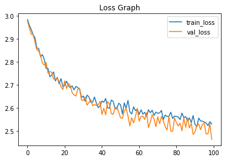

```python
def plot_loss(train,val,name1="train_loss",name2="val_loss",title=""):
    plt.title(title)
    plt.plot(train, label=name1)
    plt.plot(val, label=name2)
    plt.legend()

plot_loss(train_loss,val_loss,"train_loss","val_loss","Loss Graph")
```

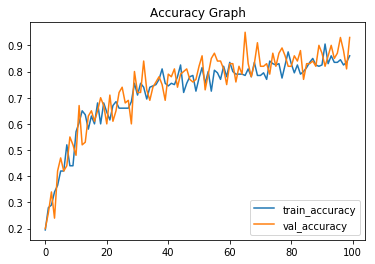

```python
plot_loss(train_accuracy,val_accuracy,"train_accuracy","val_accuracy","Accuracy Graph")
```